# Volcano Dataset

### Fourth question using standard deviation

What is the standard deviation of the longitudes, indicating the measure of dispersion of longitudes relative to the mean?

```python
import statistics

# Dados
longitudes = [131.6, -67.618, -90.876, 34.621, -121.49, 140.281, 40.84, 40.853, 145.67, -90.743, -25.47, -73.75, 115.508, 145.03, 130.657, 159.45, 139.193, 144.013, 140.799, 140.757, 129.594, -165.986, 155.565, 40.573, -91.12,
              40.631, 39.92, -78, -135.42, -91.519, 159.647, 40.553, 38.78, -163.149, 127.48, 167.835, 121.1, 124.42, 153.65, 49.15, 168.12, 77.52, -171.252, 145.67, 158.83, -72.33, -132.33, 169.78, -158.17, -72.15, -78.141,
              -67.4, -71.349, 139.759, -72.58, -89.786, -88.77, 125.269, -86.342, -67.783, 44.2, 44.3, 120.742, 42.47, -84.703, 44.08, 112.575, 120.8, 157.827, 138.523, -14.37, -16.783, 131.104, 42.43, 145.406, 130.57, -78.617,
              -174.139, -133.32, -70.05, 174.87, -153.43, 158.836, -130, 98.303, -68.237, -91.408, -70.761, 140.244, 121.94, -121.688, 155.196, 158.07, -121.813, 48.3, 147.28, 125.375, 121.48, 129.881, 140.072, -110.82, -17.516,
              158.24, 36.57, -84.1, 107.2, 115.375, -68.588, 32.75, -121.841, 160.53, -136, 146.932, 160.595, 127.725, 124.535, 155.225, 41.63, 38.98, -114.352, -112.5, -70.37, -67.765, -168.03, 157.78, 157.78, 160.02, 157.917,
              39.05, 40.987, 39.475, 3.351, -75.293, -21.783, -123.4, -26.533, 163.25, 175.911, 124.056, 30.08, 38.35, 115.133, 125.218, -71.75, 122.123, -70.496, -4.02, -72.618, -71.45, 9.17, 124.673, 121.86, 14.139, 12.7,
              -26.67, -72.07, -105.93, -77.986, -123.28, -72.27, -104.508, 36.04, 108.408, -78.25, 146.252, -71.53, -78.287, 2.97, 128.08, 157.47, -99.13, -93.228, -156.99, 155.461, -77.938, -71.378, -88.33, -89.73, -89.55,
              147.92, 150.871, 140.049, 127.33, 37.88, -122.108, -122.77, -130.3, -89.55, -129.58, 50.23, -97.15, -103.62, 12.7, -111.92, -85.622, -71.183, 38.39, -67.534, -31.111, -87.57, -78.436, -70.194, -122.12, -113.5,
              123.17, -78.364, -90.4, -77.87, -97.27, 40.48, 40.07, 150.094, 41.63, 52.109, 114.279, -91.28, 102.37, -121.82, 150.88, -60.652, 103.121, -70.75, -120.861, 44.67, -61.43, -61.397, -118.75, 109.879, 156.978,
              -70.432, 41.809, 127.894, -104.45, 158.922, 145.67, -109.38, 156.014, 36.22, -91.546, -135.75, -130.63, 42.442, 160.53, -162.073, 36.33, -129.1, 168.37, 35.447, 167.17, 40.67, 141.166, -16.583, -86.4, 14.999,
              147.131, 147.871, -19.633, 144.893, -28.73, 39.93, -164.43, -89.992, -31.216, -24.35, 30.25, -137.38, 55.708, -16.666, -162.835, -90.88, -14.02, 138.728, 128.849, -25.32, 41.27, 40.408, -86.15, -77.37, 159.73,
              108.058, 127.33, 160.703, 127.53, -123, -123, 149.511, 150.07, 167.5, 39.188, 106.965, -89.958, 45, -121.113, -97.25, -118.32, 150.35, 158.03, -27.97, -15.58, -85.98, -20.883, -17.316, -78.598, -67.566, -89.12,
              42.53, 107.84, 139.766, 140.854, 110.229, 140.877, 139.021, 136.771, -156.25, 126.53, 42.73, 151.1, 37.583, 138.851, 34.17, 108.2, 45.1, 178.973, 73.513, -19.666, -23.283, -112.45, -21.416, -18.03, 139.285,
              -27.176, -18.766, 140.677, 34.5, -121.695, -131.28, -21.333, -155.87, -72.13, -71.58, -70.85, -99.42, -72.97, -72.578, 104.59, 102.239, -97.45, 150.53, 127.63, 161.08, 31.933, 114.242, 160.77, -153.09, 123.258,
              123.38, 122.761, 123.57, -78.714, -89.053, -78.183, -163.45, -121.82, -69.9, 120.98, 120.95, 141.289, 128.223, -89.63, -83.852, -105.886, 123.38, 13.897, -130.55, 46.7, 40.2, 140.303, 141.001, -89.68, 121.641,
              113.57, -98.642, 139.394, 139.098, 140.303, 127.439, -57.75, -8.155, -66.48, -67.432, -121.8, 128.83, 99.021, -117.46, 102.615, 140.929, 173.9, 141.102, -177.168, 123.132, 106.05, 33.6, 29.45, 145.964, 43.38,
              159.443, -19.083, -154.963, 29.92, 44.5, 159.93, 158.85, 121.82, 157.35, 125.92, 112.308, 107.709, 69.5, 101.264, 152.475, 102.75, 154.508, 39.92, 157.711, -61.64, 130.305, 160.251, -155.287, 130.862, 41.38,
              139.85, 141.284, 125.031, 160.642, 150.083, 39.701, 35.88, 36.12, -174.166, 156.753, 158.05, 18.53, 139.153, -16.728, 105.423, 160.27, 150.027, -22.083, 157.572, 130.217, 129.926, 131.249, 28.52, 80.2, 140.788,
              157.12, 138.528, 144.427, 141.16, 25.85, 168.536, -16.647, 33.792, -17.83, 121.27, -85.73, 113.341, 148.42, -19.7, -71.502, -13.63, -67.73, -121.508, 111.192, 35.914, 126.047, 122.833, 159.827, -131.35, 122.775,
              -62.8, -67.88, -78.613, 152.642, 14.933, -22.483, -71.729, 124.792, 150.509, 151.158, 155.62, 147.12, 126.5, -71.586, 99.209, 37.75, 109.12, -178.475, -16.97, 124.888, 124.865, -69.832, -166.923, 159.674, -119.032,
              148.33, 145.037, 40.82, 42.2, 123.25, 5.83, 100.474, -71.167, 37.75, 120.482, -112.67, 176.08, 24.27, 37.97, -155.361, 143.031, -86.165, -104.83, 144.561, 171.32, 125.07, -70.492, -155.47, -155.608, 176.25, -123.5,
              -121.554, 37.488, 139.73, 26.47, 164.7, 110.446, 110.44, 36.75, 23.336, -72.445, -101.75, 137.59, 139.602, -128.73, 151.786, 24.439, 141.935, -85.153, 139.526, -72.027, -176.747, -78.27, -85.968, -86.539, -119.03,
              -119.029, -26.374, 163.53, 167.67, 148.838, -90.1, 29.678, 149.339, 110.88, 158.196, 139.918, 138.114, 177.98, 129.857, 36.43, 139.491, -96.75, 140.734, 139.963, 120.4, -91.17, -86.702, -86.32, 42.229, -62.58, -121.229,
              142.5, 33.554, 138.036, 139.27, 139.376, 140.659, 147.342, 27.16, -175.63, 137.554, 168.353, -104.3, 139.566, 144.043, 144.775, 37.87, 29.2, 29.25, 160.65, 38.58, -169.618, -68.541, 176.5, 133.334, -168.13, 10.5, 36.075,
              -68.413, 36.292, 157.53, 2.53, 139.507, 137.48, 157.339, -16.633, -97.27, -85.473, 139.367, 141.12, -72.496, 157.322, 157.435, -90.601, 145.8, 36.18, -69.698, -70.295, 121.708, -68.2, 15.064, 12.02, 107.73, -98.7, -69.142,
              107.4, -161.894, -69.241, -61.165, 112.62, -57.93, 106.7, 96.289, -28.4, -25.67, -86.688, -113.498, 120.35, -70.568, -61.341, -84.366, 165.5, -84.233, 123.958, 159.8, 95.25, -98.622, 45.74, 51.75, -20.666, 37.95, -28.167,
              -68.054, -78.463, -72.264, -76.4, -67.75, -72.117, -61.05, -71.722, -62.96, -71.351, 152.203, 39.78, -121.76, 120.52, 103.925, -177.92, 153.02, 114.056, 145.733, -168.539, -73.585, -108.83, 176.33, -77.656, -22.566,
              -85.324, 116.47, -86.75, 163.33, 175.57, 148.35, -75.324, 178.478, 33.668, 146.139, -63.23, -71.857, -67.892, 106.73, -115.616, 43.7, -113.75, -87.004, -89.5, -89.48, -111.678, -69.895, -114.4, -95.2, 121.3, -70.849,
              -68.391, -115.996, -89.294, -88.837, 132.622, -121.93, -78.341, 119.07, 119.986, -89.63, -90.33, -75.365, -91.552, -90.77, -89.87, 25.396, 100.189, 153.2, 148.019, -26.483, -172.525, 159.82, 46.12, -60.05, -172.51,
              104.317, 112.922, 179.58, -97.47, 130.017, -25.78, 95.658, 160.87, -122.193, 161.36, 138.519, 141.38, 145.161, -163.97, 99.255, 36.23, 123.23, -126.3, 156.52, 98.392, 98.501, -89.631, -126.67, 124.13, 109.208, 160.8,
              -110.95, -118.87, -71.52, 124.737, 99.539, -61.664, -62.18, -61.18, -27.225, -130.68, -152.251, 147.35, -61.67, -122.18, -162.12, -170.3, 15.213, -89.78, 150.942, -77.626, 101.728, 110.07, 140.051, 109.992, 167.47,
              36.357, 129.714, 120.993, -69.5, -88.532, -92.109, -69.77, -174.23, -89.9, 41.83, 142.854, 139.777, -112.08, 108.07, 99.98, 100.681, 118, -178.146, 100.331, 125.185, 107.6, 154.7, 127.83, 174.07, 99.95, 121.553,
              -169.454, 176, -179.97, -88.502, -90.407, -86.84, 110.4, 96.821, 43.874, -16.641, 98.5, 112.95, -85.015, 35.43, -27.32, -17.166, -121.767, 127.4, -88.43, -87.641, -68.13, 165.804, -19.716, -70.352, 160.108, -17.118,
              -133.3, 98.83, 127.47, 8.5, -175.07, 16.33, 142.686, 160.326, -71.645, -75.33, -91.189, -99.758, 145.504, 9.717, 124.83, -115.83, 175.632, -19.122, 139.279, 16.45, 140.88, 140.839, 169.238, -70.898, -155.1, -12.28,
              -61.33, -70.906, -70.033, -71.885, 39.137, -17.916, 102.5, -69.797, -83.767, -170.7, -70.372, -130.58, -66.48, 159.967, -117.45, 160.527, 117.77, -156.368, -113.13, -156.51, 158.38, 130.87, 147.875, 110.33, 130.299,
              -171.72, 152.25, 160.509, -88.471, -86.882, 37.25, 159.97, -169.058, 45.497, 46.942, -80.17, 155.97, -20.266, 14.426, 149.07, -71.93, 158.28, 29.485, 157.93, 113.25, 17.28, 160.631, 14.962, 11.93, 160.765, -126.88,
              -176.17, -113.22, 137.594, -61.305, -120.57, -122.08, 6.85, -173.75, -164.65, 177.18, 174.27, 111.758, 150.516, -144.017, 126.12, 137.587, 42.83, 169.447, 156.629, -110.67, -87.98, 128.997, 138.32, 130.592, 140.812,
              -70.196, 131.39, -170.629, -87.63, 140.44, 159.95, -85.82, 158.385, -27.57, 160.603, -100.25, 42.18, 42.75, -108]



# Calculate the standard deviation
standard_deviation = statistics.stdev(longitudes)

print(f"The standard deviation of the longitudes is: {standard_deviation:.2f}")
```

```
The standard deviation of the longitudes is: 109.85
```

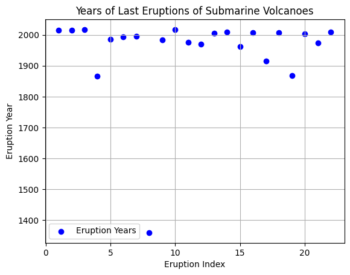

```python
import matplotlib.pyplot as plt

# Data for the years of the last eruptions of submarine volcanoes
last_eruption_years = [2014, 2015, 2017, 1867, 1986, 1993, 1996, 1360, 1984, 2017, 1975, 1970, 2006, 2010, 1962, 2008, 1916, 2008, 1868, 2003, 1973, 2009]

# Scatter plot
plt.scatter(range(1, len(last_eruption_years) + 1), last_eruption_years, color='blue', marker='o', label='Eruption Years')
plt.xlabel('Eruption Index')
plt.ylabel('Eruption Year')
plt.title('Years of Last Eruptions of Submarine Volcanoes')
plt.legend()
plt.grid(True)
plt.show()
```

### Sixth question with graph

What is the elevation of a 'Maars' volcano relative to sea level, represented in a line graph showing the elevation?

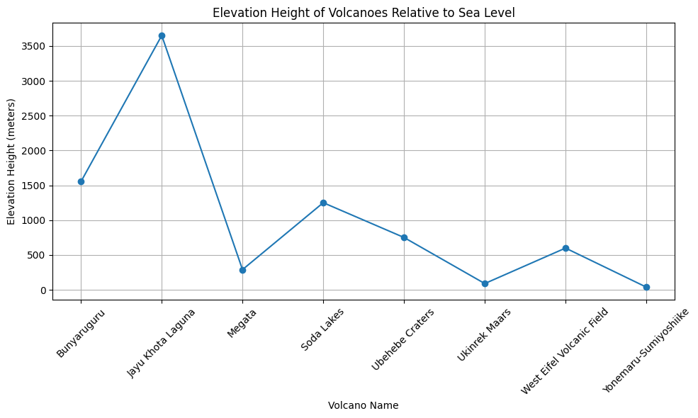

```python
import matplotlib.pyplot as plt

# Data for volcano names and elevations above sea level
volcano_names = ["Bunyaruguru", "Jayu Khota Laguna", "Megata", "Soda Lakes", "Ubehebe Craters", "Ukinrek Maars", "West Eifel Volcanic Field", "Yonemaru-Sumiyoshiike"]
elevations = [1554, 3650, 291, 1251, 752, 91, 600, 40]

# Plot
plt.figure(figsize=(10, 6))
plt.plot(volcano_names, elevations, marker='o', linestyle='-')
plt.title("Elevation Height of Volcanoes Relative to Sea Level")
plt.xlabel("Volcano Name")
plt.ylabel("Elevation Height (meters)")
plt.xticks(rotation=45)
plt.grid(True)
plt.tight_layout()
plt.show()
```

### Seventh question using correlation analysis

Is there any correlation between latitude and elevation of volcanoes for this dataset of 'caldera' type volcanoes? In other words, as we move from the equator (lower latitude) to more polar regions (higher latitude), does the elevation of the volcanoes vary significantly?

```python
import pandas as pd

# Dataset used for correlation analysis between elevation and latitude variables
data = {
    'latitude': [38.537, 31.593, 43.384, 56.88, 32.884, 31.22, -34.65, -4.523, -8.242, -26.789, -8.283, -35.558, 40.827, -0.375, 46.532, 13.87, 41.73, 7.193, 42.93, 0.308, -5.094, -63.001, 55.341, 8.357, 52.559, 64.416, -5.334, 19.68,
                 13.672, 24.751, 30.793, 8.788, 65.715, -6.102, 54.596, 51.45, 43.615, -16.829, 14.42, -4.92, -30.21, -34.164, 54.135, -38.42, 11.985, 43.572, -36.058, 38.729, -8.989, 7.47, 52.543, 0.038, 13.83, -4.871, -38.42, -8.724,
                 -5.107, 42.688, 51.43, 3.248, -38.97, 14.002, -38.82, 2.58, 1.25, -19.75, 43.844, 1.23, 40.51, 54.5, 42.6, -5.576, 44.43, 19.4],

   'elevation': [1683, 1117, 1499, 1341, 1592, 924, 5189, 596, 1717, 4670, 2244, 3508, 458, 4643, 742, 746, 949, 2320, 2487, 3246, 408, 602, 1436, 1873, 1799, 1719, 849, 3150, 450, 169, 704, 1380, 800, 155, 1816, 81, 574, -2, 743, 858,
                 238, 5323, 1527, 897, 594, 857, 2162, 470, 2614, 2075, 2439, 3356, 777, 1854, 592, 1319, 1717, 1320, 3160, 2181, 2282, 311, 760, 2157, 979, 515, 535, 1202, 1011, 1617, 800, 724, 2805, 3500]
}

df = pd.DataFrame(data)

# Calculation and correlation
correlation = df['latitude'].corr(df['elevation'])

print(f"Correlation between latitude and elevation: {correlation}")
```

```
Correlation between latitude and elevation: -0.18743562956584398
```

### Eighth question using linear regression

Is it possible to predict the longitude of a volcano in the 'Africa and Red Sea' region based on its latitude using a linear regression analysis?

```
Predicted Longitude: 33.81023665955216
```

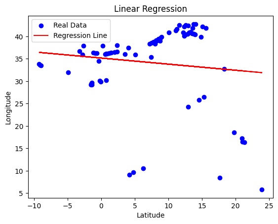

```python
import pandas as pd
from sklearn.linear_model import LinearRegression
import matplotlib.pyplot as plt

# Dataset for linear regression analysis
data = {
    'latitude': [10.07, 13.088, 12.888, 13.512, 14.88, 13.793, 7.77, 11.58, 12.95, 2.32, 18.33, 8.78, 8.221, 13.304, 8.558, -0.2, 8.05, 4.203, 3.496, -2.68, 7.193, 12.595, 12.38, 11.28, 13.579, -0.65, 1.5, 13.6, 8.975, 0.7, 11.08, 13.975, 8.357, 12.55, 13.72, -0.38, -4.889, -1.506, -0.08, 8.788, 5.1, 0.77, 19.8, 14.57, -9.229, -2.764, 12.17, 12.38, 23.92, 12.95, 2.32, 4.063, 15.32, -3.25, -1.383, 1.98, -8.989, 0.23, -1.408, -1.52, 7.47, 6.25, 0.62, -0.904, 0.92, -9.135, 1.15, -1.151, 15.55, 7.42, 17.68, 21.33, 4.758, 21.03, 8.159, -1.458, 20.92, 15.05, 14.02],
    'longitude': [40.84, 40.853, 40.573, 40.631, 39.92, 40.553, 38.78, 42.47, 42.43, 36.57, 32.75, 38.98, 39.05, 40.987, 39.475, 30.08, 38.35, 9.17, 36.04, 37.88, 38.39, 40.48, 40.07, 41.63, 41.809, 36.22, 36.33, 40.67, 39.93, 30.25, 41.27, 40.408, 39.188, 42.53, 42.73, 34.5, 31.933, 29.45, 29.92, 39.701, 35.88, 36.12, 18.53, 25.85, 33.792, 35.914, 40.82, 42.2, 5.83, 24.27, 37.97, 37.488, 26.47, 36.75, 29.678, 36.43, 33.554, 37.87, 29.2, 29.25, 38.58, 10.5, 36.075, 36.292, 36.18, 33.668, 36.23, 36.357, 41.83, 35.43, 8.5, 16.33, 9.717, 16.45, 39.137, 29.485, 17.28, 42.18, 42.75]
}

df = pd.DataFrame(data)

# Splitting data into features (latitude) and labels (longitude)
X = df[['latitude']]
y = df['longitude']

model = LinearRegression()  # Creating a linear regression model
model.fit(X, y)  # Training the model with the provided data
latitudes_to_predict = [[10.0]]
predicted_longitudes = model.predict(latitudes_to_predict)

# Displaying the result
print(f"Predicted Longitude: {predicted_longitudes[0]}")

# Plot
plt.scatter(X, y, color='blue', label='Real Data')
plt.plot(X, model.predict(X), color='red', label='Regression Line')
plt.xlabel('Latitude')
plt.ylabel('Longitude')
plt.title('Linear Regression')
plt.legend()
plt.show()
```

© [Matheus Santos] All rights reserved